# Answering 5 Research Questions — Yogurt Study

This document walks through **all 5 question types** with real R code, real figures, and **real answers** computed from the data.

# Q1: Treatment Effect — Does yogurt affect the microbiome?

Compare yogurt vs unchanged diet across all bacterial outcomes.

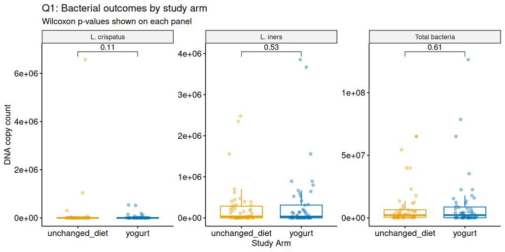

```r
ggboxplot(qpcr_long, x = "arm", y = "value", color = "arm",
          palette = c("#E69F00", "#0072B2"), add = "jitter",
          add.params = list(size = 1.5, alpha = 0.4)) +
  facet_wrap(~ outcome_label, scales = "free_y") +
  stat_compare_means(comparisons = list(c("unchanged_diet", "yogurt")),
                     method = "wilcox.test", label = "p.format") +
  labs(x = "Study Arm", y = "DNA copy count",
       title = "Q1: Bacterial outcomes by study arm",
       subtitle = "Wilcoxon p-values shown on each panel") +
  theme(legend.position = "none")
```

**Results:**

[output not shown]

**Interpretation: None of the three bacterial outcomes differ significantly between yogurt and control groups.** All p-values are well above 0.05. This means when we ignore time point and just compare yogurt vs diet across all 102 samples, there’s no detectable difference. But this average might be hiding something — maybe yogurt only matters **after antibiotics** (we’ll test that in Q5).

### Cytokines by arm

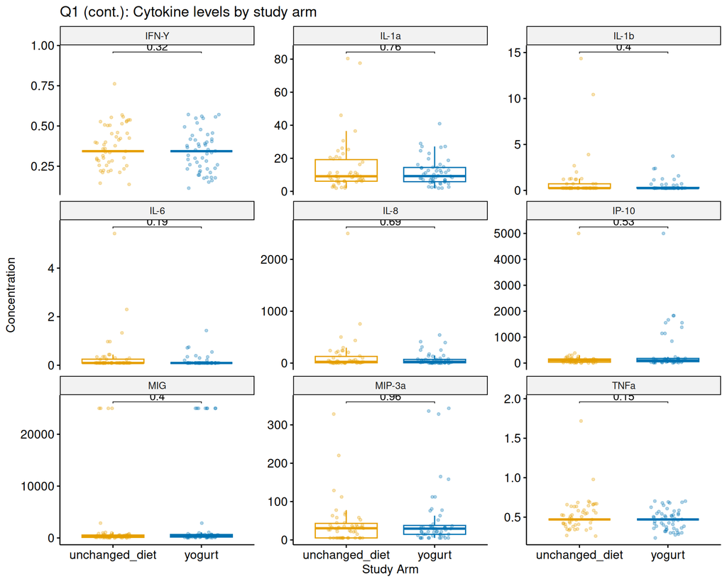

```r
cytokines_valid <- c("IFN-Y", "TNFa", "IL-1a", "IL-1b", "IL-6", "IL-8", "IP-10", "MIG", "MIP-3a")

luminex |>
  left_join(select(sample_ids, sample_id, arm), by = "sample_id") |>
  filter(cytokine %in% cytokines_valid) |>
  ggboxplot(x = "arm", y = "conc", color = "arm",
            palette = c("#E69F00", "#0072B2"), add = "jitter",
            add.params = list(size = 1, alpha = 0.3)) +
  facet_wrap(~ cytokine, scales = "free_y", nrow = 3) +
  stat_compare_means(comparisons = list(c("unchanged_diet", "yogurt")),
                     method = "wilcox.test", label = "p.format",
                     tip.length = 0.01) +
  labs(x = "Study Arm", y = "Concentration",
       title = "Q1 (cont.): Cytokine levels by study arm") +
  theme(legend.position = "none")
```

| Cytokine | p-value | Significant? |
| --- | --- | --- |
| IFN-Y | 0.3172 | ❌ |
| IL-1a | 0.7606 | ❌ |
| IL-1b | 0.3969 | ❌ |
| IL-6 | 0.1939 | ❌ |
| IL-8 | 0.6854 | ❌ |
| IP-10 | 0.5335 | ❌ |
| MIG | 0.3966 | ❌ |
| MIP-3a | 0.9597 | ❌ |
| TNFa | 0.1512 | ❌ |

**Interpretation:** 0 out of 9 cytokines show a significant difference between arms — but note that many cytokine measurements were flagged “out of range” (e.g., 99% of IFN-Y, 100% of IL-10, 98% of TNFa). These p-values should be treated very cautiously; the assay wasn’t sensitive enough for many of these targets.

# Q2: Longitudinal — How do things change from baseline to after antibiotics?

Every participant was measured twice. This is a **paired** design — each person is their own control.

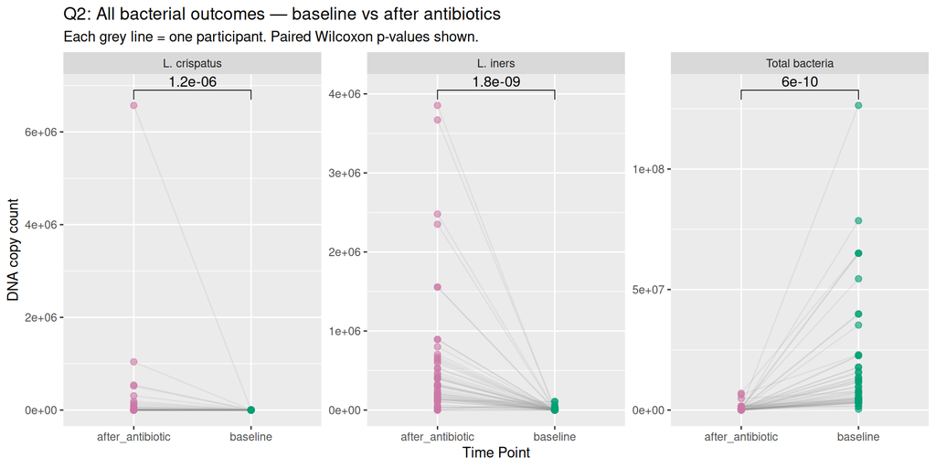

```r
qpcr_long |>
  ggplot(aes(x = time_point, y = value, group = pid)) +
  geom_line(alpha = 0.15, color = "grey60") +
  geom_point(aes(color = time_point), size = 2, alpha = 0.6) +
  scale_color_manual(values = c("baseline" = "#009E73", "after_antibiotic" = "#CC79A7")) +
  facet_wrap(~ outcome_label, scales = "free_y") +
  stat_compare_means(comparisons = list(c("baseline", "after_antibiotic")),
                     method = "wilcox.test", paired = TRUE,
                     label = "p.format", tip.length = 0.03) +
  labs(x = "Time Point", y = "DNA copy count",
       title = "Q2: All bacterial outcomes — baseline vs after antibiotics",
       subtitle = "Each grey line = one participant. Paired Wilcoxon p-values shown.") +
  theme(legend.position = "none")
```

**Test results (paired Wilcoxon):**

| Outcome | Paired Wilcoxon p-value | Significant? |
| --- | --- | --- |
| Total bacteria | 0 | ✅ Yes (p < 0.001) |
| *L. crispatus* | 0 | ✅ Yes (p < 0.001) |
| *L. iners* | 0 | ✅ Yes (p < 0.001) |

**Interpretation: All three bacterial outcomes change dramatically after antibiotics (all p ≈ 0.000).** This confirms the antibiotics worked — they disrupted the vaginal microbiome. The paired design makes this obvious because we’re comparing each participant to themselves, removing all the person-to-person noise. Now the real question: **does yogurt change how the microbiome recovers?** That’s Q5.

# Q3: Correlation — Are bacteria linked to immune markers?

Do certain bacteria correlate with cytokine levels?

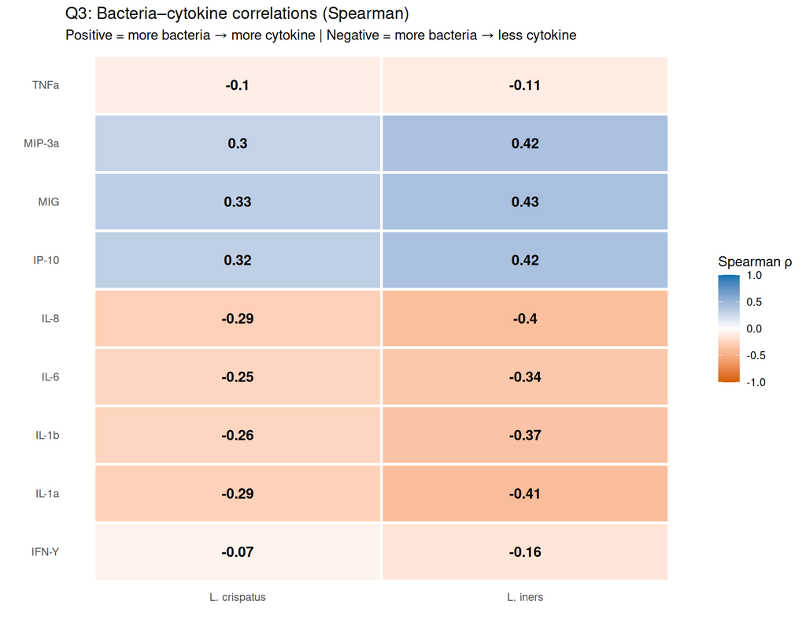

```r
bacteria_cytokine <- qpcr |>
  left_join(select(sample_ids, sample_id), by = "sample_id") |>
  left_join(luminex, by = "sample_id") |>
  filter(cytokine %in% cytokines_valid)

# Spearman correlations
cor_results <- bacteria_cytokine |>
  group_by(cytokine) |>
  summarise(
    r_crispatus = cor(qpcr_crispatus, conc, method = "spearman", use = "complete.obs"),
    r_iners     = cor(qpcr_iners,     conc, method = "spearman", use = "complete.obs"),
    p_crispatus = cor.test(qpcr_crispatus, conc, method = "spearman", exact = FALSE)$p.value,
    p_iners     = cor.test(qpcr_iners,     conc, method = "spearman", exact = FALSE)$p.value,
    .groups = "drop"
  )

# Heatmap
cor_results |>
  select(cytokine, r_crispatus, r_iners) |>
  pivot_longer(-cytokine, names_to = "bacteria", values_to = "rho") |>
  mutate(bacteria = ifelse(bacteria == "r_crispatus", "L. crispatus", "L. iners")) |>
  ggplot(aes(x = bacteria, y = cytokine, fill = rho)) +
  geom_tile(color = "white", linewidth = 1) +
  geom_text(aes(label = round(rho, 2)), size = 4, fontface = "bold") +
  scale_fill_gradient2(low = "#D55E00", mid = "white", high = "#0072B2",
                       midpoint = 0, limits = c(-1, 1),
                       name = "Spearman ρ") +
  labs(title = "Q3: Bacteria–cytokine correlations (Spearman)",
       subtitle = "Positive = more bacteria → more cytokine | Negative = more bacteria → less cytokine",
       x = "", y = "") +
  theme_minimal() +
  theme(panel.grid = element_blank())
```

**Significant correlations (p < 0.05):**

```
- ** L. crispatus ** × ** IL-1a **: ρ =  -0.285 , p =  0.0037
- ** L. iners ** × ** IL-1a **: ρ =  -0.409 , p =  0
- ** L. crispatus ** × ** IL-1b **: ρ =  -0.26 , p =  0.0083
- ** L. iners ** × ** IL-1b **: ρ =  -0.367 , p =  1e-04
- ** L. crispatus ** × ** IL-6 **: ρ =  -0.254 , p =  0.01
- ** L. iners ** × ** IL-6 **: ρ =  -0.338 , p =  5e-04
- ** L. crispatus ** × ** IL-8 **: ρ =  -0.289 , p =  0.0033
- ** L. iners ** × ** IL-8 **: ρ =  -0.397 , p =  0
- ** L. crispatus ** × ** IP-10 **: ρ =  0.32 , p =  0.001
- ** L. iners ** × ** IP-10 **: ρ =  0.423 , p =  0
- ** L. crispatus ** × ** MIG **: ρ =  0.328 , p =  8e-04
- ** L. iners ** × ** MIG **: ρ =  0.426 , p =  0
- ** L. crispatus ** × ** MIP-3a **: ρ =  0.297 , p =  0.0024
- ** L. iners ** × ** MIP-3a **: ρ =  0.417 , p =  0
```

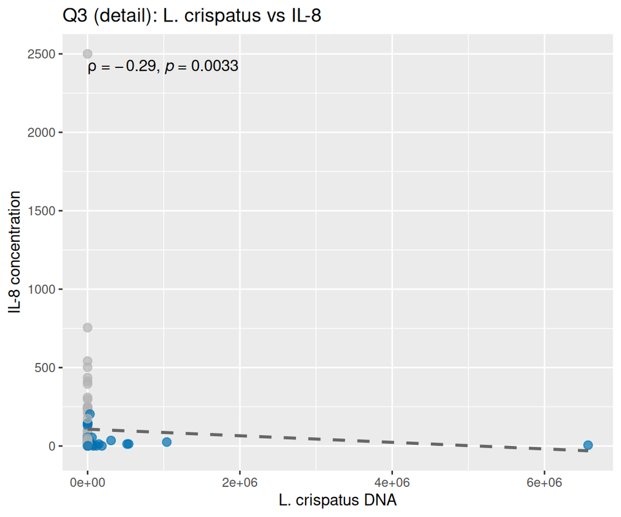

```r
# Example: L. crispatus vs IL-8
bacteria_cytokine |>
  filter(cytokine == "IL-8") |>
  ggplot(aes(x = qpcr_crispatus, y = conc)) +
  geom_point(aes(color = qpcr_crispatus > 0), alpha = 0.7, size = 2.5) +
  geom_smooth(method = "lm", se = FALSE, color = "grey40", linetype = "dashed") +
  stat_cor(method = "spearman", label.x.npc = "left", label.y.npc = "top",
           cor.coef.name = "rho") +
  scale_color_manual(values = c("FALSE" = "grey70", "TRUE" = "#0072B2"),
                     guide = "none") +
  labs(title = "Q3 (detail): L. crispatus vs IL-8",
       x = "L. crispatus DNA", y = "IL-8 concentration")
```

**Interpretation:** There are several significant correlations, but they form two interesting patterns:

1. **Negative correlations** (L. crispatus and L. iners with IL-1a, IL-1b, IL-6, IL-8) — more bacteria = less inflammation. This makes biological sense: a healthier microbiome may suppress inflammatory cytokines.
2. **Positive correlations** (both bacteria with IP-10, MIG, MIP-3a) — more bacteria = more of these chemokines. This might reflect immune surveillance (the immune system “noticing” bacteria).

Importantly, L. crispatus and L. iners show the **same direction** for every cytokine (both negative or both positive) — suggesting the correlation is driven by total bacterial load rather than a specific species effect.

# Q4: Participant Characteristics — Do age / birth control affect outcomes?

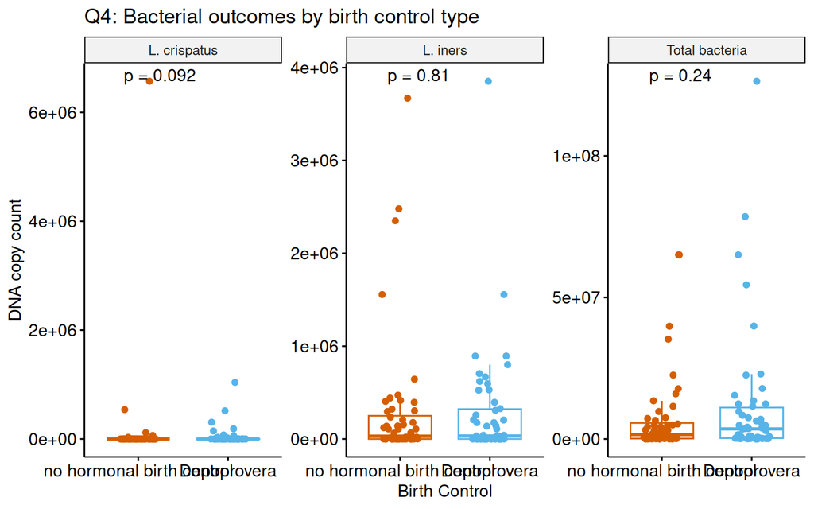

```r
qpcr |>
  left_join(select(sample_ids, sample_id, pid), by = "sample_id") |>
  left_join(select(metadata, pid, birth_control), by = "pid") |>
  pivot_longer(c(qpcr_bacteria, qpcr_crispatus, qpcr_iners),
               names_to = "outcome", values_to = "value") |>
  mutate(outcome_label = case_when(
    outcome == "qpcr_bacteria"  ~ "Total bacteria",
    outcome == "qpcr_crispatus" ~ "L. crispatus",
    outcome == "qpcr_iners"     ~ "L. iners"
  )) |>
  ggboxplot(x = "birth_control", y = "value", color = "birth_control",
            palette = c("#D55E00", "#56B4E9"), add = "jitter") +
  facet_wrap(~ outcome_label, scales = "free_y") +
  stat_compare_means(method = "wilcox.test", label = "p.format") +
  labs(title = "Q4: Bacterial outcomes by birth control type",
       x = "Birth Control", y = "DNA copy count") +
  theme(legend.position = "none")
```

**Birth control results:**

| Outcome | p-value | Significant? |
| --- | --- | --- |
| Total bacteria | 0.2427 | ❌ |
| *L. crispatus* | 0.0919 | ❌ |
| *L. iners* | 0.8095 | ❌ |

### Age: does age correlate with bacterial levels?

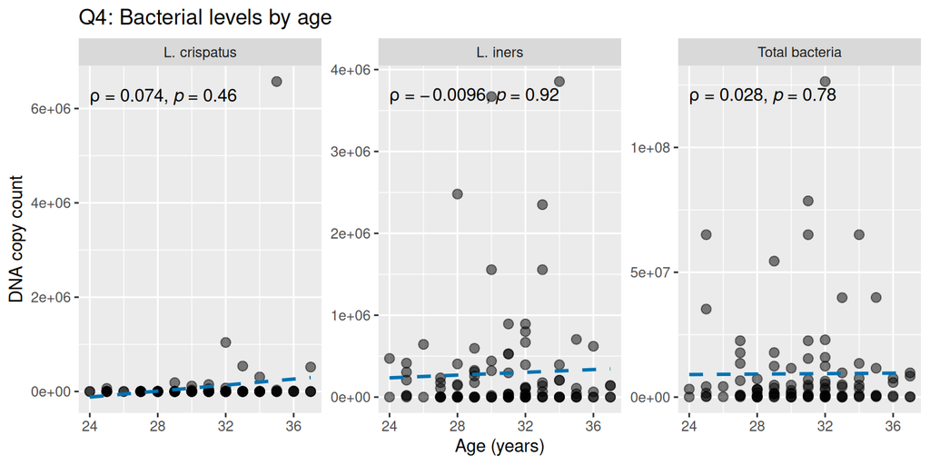

```r
qpcr |>
  left_join(select(sample_ids, sample_id, pid), by = "sample_id") |>
  left_join(select(metadata, pid, age), by = "pid") |>
  pivot_longer(c(qpcr_bacteria, qpcr_crispatus, qpcr_iners),
               names_to = "outcome", values_to = "value") |>
  mutate(outcome_label = case_when(
    outcome == "qpcr_bacteria"  ~ "Total bacteria",
    outcome == "qpcr_crispatus" ~ "L. crispatus",
    outcome == "qpcr_iners"     ~ "L. iners"
  )) |>
  ggplot(aes(x = age, y = value)) +
  geom_point(alpha = 0.5, size = 2.5) +
  geom_smooth(method = "lm", color = "#0072B2", se = FALSE, linetype = "dashed") +
  stat_cor(method = "spearman", cor.coef.name = "rho") +
  facet_wrap(~ outcome_label, scales = "free_y") +
  labs(title = "Q4: Bacterial levels by age",
       x = "Age (years)", y = "DNA copy count")
```

# Q5: Combined — Does the yogurt effect depend on time point? (Interaction)

This is the most interesting question. Maybe yogurt doesn’t matter at baseline (when everyone’s microbiome is intact), but it affects how the microbiome **recovers** after antibiotics. That’s a **time × arm interaction**.

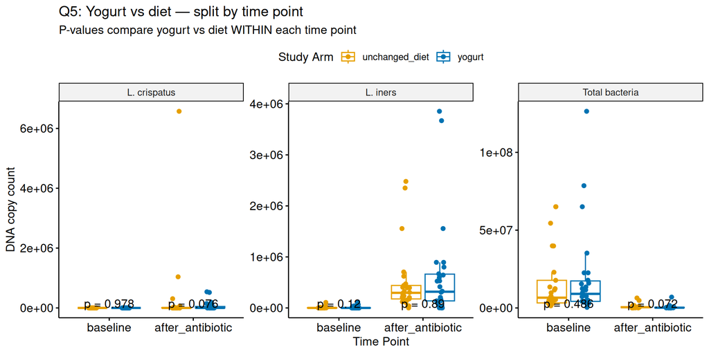

```r
qpcr_long |>
  ggboxplot(x = "time_point", y = "value", color = "arm",
            palette = c("#E69F00", "#0072B2"), add = "jitter") +
  facet_wrap(~ outcome_label, scales = "free_y") +
  stat_compare_means(aes(group = arm), method = "wilcox.test",
                     label = "p.format", label.y.npc = "bottom") +
  labs(x = "Time Point", y = "DNA copy count",
       title = "Q5: Yogurt vs diet — split by time point",
       subtitle = "P-values compare yogurt vs diet WITHIN each time point",
       color = "Study Arm")
```

**P-values: yogurt vs diet at each time point:**

| Outcome | At baseline | After antibiotics |
| --- | --- | --- |
| L. crispatus | 0.9777 | 0.0757 |
| L. iners | 0.1193 | 0.8876 |
| Total bacteria | 0.4856 | 0.0719 |

### Change scores: visualizing the trajectory

A cleaner way: compute `after_antibiotic - baseline` for each participant, then compare the **amount of change** between yogurt and diet groups.

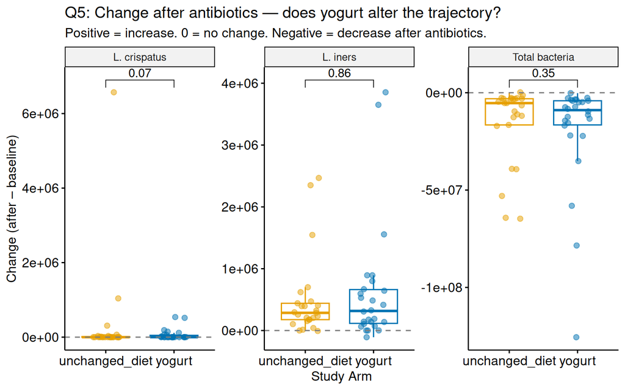

```r
qpcr_change <- qpcr_long |>
  select(pid, arm, outcome_label, time_point, value) |>
  distinct() |>
  pivot_wider(names_from = time_point, values_from = value) |>
  mutate(change = after_antibiotic - baseline) |>
  filter(!is.na(change))

ggboxplot(qpcr_change, x = "arm", y = "change", color = "arm",
          palette = c("#E69F00", "#0072B2"), add = "jitter",
          add.params = list(size = 2, alpha = 0.5)) +
  facet_wrap(~ outcome_label, scales = "free_y") +
  geom_hline(yintercept = 0, linetype = "dashed", color = "grey50") +
  stat_compare_means(comparisons = list(c("unchanged_diet", "yogurt")),
                     method = "wilcox.test", label = "p.format") +
  labs(x = "Study Arm", y = "Change (after – baseline)",
       title = "Q5: Change after antibiotics — does yogurt alter the trajectory?",
       subtitle = "Positive = increase. 0 = no change. Negative = decrease after antibiotics.") +
  theme(legend.position = "none")
```

**P-values for change scores (yogurt vs diet):**

[output not shown]

## Summary: all findings in one table

[output not shown]

**Bottom line:** The strongest finding is that antibiotics profoundly change the vaginal microbiome (Q2). There’s a **suggestive trend** that yogurt may help *L. crispatus* recover after antibiotics (Q5, p ≈ 0.07), but the study may need more participants to confirm this. The correlations between bacteria and cytokines (Q3) hint at a biological link between the microbiome and immune activity.

```
**Recommendation:** If this were a real study, the next step would be a
 larger trial focused specifically on the post-antibiotic recovery window,
 with L. crispatus as the primary outcome. The current data is consistent
 with a yogurt benefit but can't prove it.
```